# Pixiedust

```python
import pandas as pd

import pixiedust
```

[output not shown]

[figure not shown]

Pixiedust version 1.1.17

```
Pixiedust runtime updated. Please restart kernel
Table USER_PREFERENCES created successfully
Table service_connections created successfully
```

```python
import pandas as pd
features = ["Age", "Workclass", "fnlwgt", "Education", "Education-Num", "Marital Status",
            "Occupation", "Relationship", "Race", "Sex", "Capital Gain", "Capital Loss",
            "Hours per week", "Country", "Target"]
train_data = pd.read_csv(
    "https://archive.ics.uci.edu/ml/machine-learning-databases/adult/adult.data",
    names=features,
    sep=r'\s*,\s*',
    engine='python',
    na_values="?")
```

### This gives a clear picture of schema and tabs that are available and will actually give the option to choose charts, filter accordingly

### Show rows gives an option to visualize missing values and non missing values

```python
display(train_data)
```

*Hey, there's something awesome here! To see it, open this notebook outside GitHub, in a viewer like Jupyter*

**Schema**

Field types:

**Age:** int64

**Workclass:** object

**fnlwgt:** int64

**Education:** object

**Education-Num:** int64

**Marital Status:** object

**Occupation:** object

**Relationship:** object

**Race:** object

**Sex:** object

**Capital Gain:** int64

**Capital Loss:** int64

**Hours per week:** int64

**Country:** object

**Target:** object

**Table**

Showing 100 of 32561 rows

Age

Workclass

fnlwgt

Education

Education-Num

Marital Status

Occupation

Relationship

Race

Sex

Capital Gain

Capital Loss

Hours per week

Country

Target

| Age | Workclass | fnlwgt | Education | Education-Num | Marital Status | Occupation | Relationship | Race | Sex | Capital Gain | Capital Loss | Hours per week | Country | Target |
| --- | --- | --- | --- | --- | --- | --- | --- | --- | --- | --- | --- | --- | --- | --- |
| 59 | Self-emp-not-inc | 80467 | HS-grad | 9 | Divorced | Other-service | Own-child | White | Female | 0 | 0 | 24 | United-States | <=50K |
| 17 | Private | 275051 | 11th | 7 | Never-married | Adm-clerical | Own-child | White | Female | 0 | 0 | 8 | United-States | <=50K |
| 47 | Private | 362654 | HS-grad | 9 | Married-civ-spouse | Machine-op-inspct | Husband | White | Male | 0 | 0 | 40 | United-States | <=50K |
| 26 | Private | 244495 | 9th | 5 | Never-married | Other-service | Not-in-family | White | Male | 0 | 0 | 35 | United-States | <=50K |
| 19 | Private | 194905 | Some-college | 10 | Never-married | Other-service | Own-child | White | Female | 0 | 0 | 30 | United-States | <=50K |
| 43 | Private | 219307 | 9th | 5 | Divorced | Transport-moving | Not-in-family | Black | Male | 0 | 0 | 40 | United-States | <=50K |
| 52 | Local-gov | 143533 | 7th-8th | 4 | Never-married | Other-service | Other-relative | Black | Female | 0 | 0 | 40 | United-States | <=50K |
| 32 | Self-emp-not-inc | 103642 | HS-grad | 9 | Married-civ-spouse | Exec-managerial | Husband | White | Male | 0 | 0 | 55 | United-States | <=50K |
| 27 | Local-gov | 134813 | Masters | 14 | Never-married | Prof-specialty | Own-child | White | Male | 0 | 0 | 52 | United-States | <=50K |
| 36 | Private | 70282 | Some-college | 10 | Divorced | Adm-clerical | Unmarried | Black | Female | 0 | 0 | 40 | United-States | <=50K |
| 35 | Private | 194690 | 7th-8th | 4 | Divorced | Tech-support | Unmarried | White | Female | 0 | 0 | 40 | United-States | <=50K |
| 90 | Private | 52386 | Some-college | 10 | Never-married | Other-service | Not-in-family | Asian-Pac-Islander | Male | 0 | 0 | 35 | United-States | <=50K |
| 18 | Private | 170183 | HS-grad | 9 | Never-married | Other-service | Own-child | White | Female | 0 | 0 | 20 | United-States | <=50K |
| 28 | Private | 192932 | Bachelors | 13 | Never-married | Prof-specialty | Not-in-family | White | Female | 0 | 0 | 40 | United-States | <=50K |
| 49 | Private | 195554 | HS-grad | 9 | Married-civ-spouse | Transport-moving | Husband | White | Male | 0 | 0 | 44 | United-States | <=50K |
| 73 | Self-emp-not-inc | 177387 | HS-grad | 9 | Married-civ-spouse | Exec-managerial | Husband | White | Male | 0 | 0 | 40 | United-States | <=50K |
| 24 | State-gov | 184216 | Some-college | 10 | Never-married | Adm-clerical | Own-child | White | Female | 0 | 0 | 40 | United-States | <=50K |
| 54 | State-gov | 187686 | Some-college | 10 | Divorced | Adm-clerical | Not-in-family | White | Female | 0 | 0 | 38 | United-States | <=50K |
| 36 | Private | 156352 | 9th | 5 | Never-married | Handlers-cleaners | Own-child | White | Male | 0 | 0 | 40 | United-States | <=50K |
| 27 | Self-emp-not-inc | 411950 | Some-college | 10 | Married-civ-spouse | Other-service | Husband | White | Male | 0 | 0 | 40 | United-States | <=50K |
| 19 | Private | 274657 | 5th-6th | 3 | Never-married | Other-service | Not-in-family | White | Male | 0 | 0 | 50 | Guatemala | <=50K |
| 34 | Private | 185216 | Some-college | 10 | Never-married | Adm-clerical | Own-child | White | Male | 0 | 0 | 40 | United-States | <=50K |
| 38 | Private | 141550 | 10th | 6 | Divorced | Craft-repair | Not-in-family | White | Male | 0 | 0 | 40 | United-States | <=50K |
| 29 | Private | 192283 | Some-college | 10 | Never-married | Other-service | Other-relative | White | Female | 0 | 0 | 20 | United-States | <=50K |
| 32 | Private | 164190 | HS-grad | 9 | Married-civ-spouse | Handlers-cleaners | Husband | White | Male | 0 | 0 | 30 | United-States | <=50K |
| 29 | Private | 276345 | HS-grad | 9 | Never-married | Prof-specialty | Not-in-family | White | Female | 0 | 0 | 50 | United-States | <=50K |
| 27 | nan | 291547 | Bachelors | 13 | Married-civ-spouse | nan | Not-in-family | Other | Female | 0 | 0 | 6 | Mexico | <=50K |
| 31 | Private | 43819 | Bachelors | 13 | Married-civ-spouse | Prof-specialty | Wife | White | Female | 7688 | 0 | 43 | United-States | >50K |
| 26 | Private | 139116 | Some-college | 10 | Never-married | Other-service | Own-child | Black | Female | 0 | 0 | 50 | United-States | <=50K |
| 18 | Private | 110230 | 10th | 6 | Never-married | Other-service | Own-child | White | Male | 0 | 0 | 11 | United-States | <=50K |

[output cut: 70 more lines]

### Inferences using the charts that are available on adult data set of US

#### The interface is very interactive and I clicked on bar chart to visualize my inputs, in which my key is age, value is hours of work and aggregated it to avg (Aggregation options are also available)

#### Cluster by gives an option to cluster the data based on any variable.

#### Type is divided to grouping, stacking and sub plots. User can choose according to their requirement

#### Data can be sorted using keys ASC, keys DESC, values ASC, values DESC

```python
display(train_data)
```

*Hey, there's something awesome here! To see it, open this notebook outside GitHub, in a viewer like Jupyter*

*Hey, there's something awesome here! To see it, open this notebook outside GitHub, in a viewer like Jupyter*

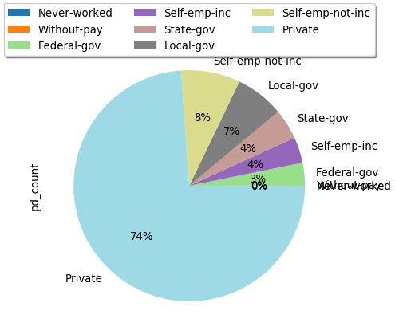

```python
display(train_data)
```

#### 74 % Adults of the data work for Private sector

*Hey, there's something awesome here! To see it, open this notebook outside GitHub, in a viewer like Jupyter*

Distributions

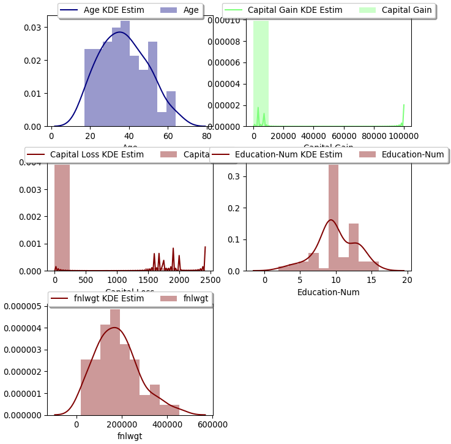

```python
display(train_data)
```

```python
display(train_data) # This graph is to visualize capital loss of different workclass across age
```

*Hey, there's something awesome here! To see it, open this notebook outside GitHub, in a viewer like Jupyter*